# Sierra Leone Covid-19 Dashboard

Tracking Economic Consequences and Responses to COVID-19 in Sierra Leone

Continuous access to information on key economic indicators is essential to help Sierra Leone respond to the Covid-19 pandemic.

This dashboard provides real time data on current economic conditions and trends from a phone based survey being rolled out in 195 towns and villages across Sierra Leone.

**Important**: Data below is fabricated—it is only used for setting up this dashboard![^1]

## markets

### Current averages

Mean responses in each District (most recent date)

| District | Date | Market open? | Market days | Is rice available? | Is casava available? | Is Bonga fish available? | Is palm oil available? | Is maggie available? | Price of rice cup | Price of casava tuber | Price of Bonga fish | Price of palm oil pint | Price of Maggie cube |
| --- | --- | --- | --- | --- | --- | --- | --- | --- | --- | --- | --- | --- | --- |
| Kailahun | 2020-04-30 | 0.60 | 6.33 | 0.78 | 0.56 | 0.67 | 0.44 | 0.67 | 2214.29 | 719.80 | 3333.33 | 1899.75 | 750.00 |
| Kenema | 2020-04-30 | 1.00 | 6.33 | 0.33 | 1.00 | 0.33 | 1.00 | 1.00 | 2000.00 | 550.00 | 5000.00 | 2000.00 | 833.33 |
| Kono | 2020-04-30 | 0.83 | 6.00 | 0.20 | 0.00 | 0.00 | 0.20 | 0.40 | 2000.00 | NaN | NaN | 2000.00 | 500.00 |
| Bombali | 2020-04-30 | 0.80 | 6.75 | 1.00 | 0.00 | 0.50 | 1.00 | 1.00 | 2000.00 | NaN | 3500.00 | 3375.00 | 2000.00 |
| Kambia | 2020-04-30 | 0.80 | 6.25 | 0.88 | 0.75 | 0.88 | 1.00 | 1.00 | 1785.71 | 368.00 | 15214.29 | 2387.75 | 1813.38 |
| Koinadugu | 2020-04-30 | 0.79 | 6.27 | 0.91 | 0.45 | 0.91 | 0.91 | 0.82 | 1900.00 | 404.00 | 3196.00 | 3000.00 | 422.22 |
| Port Loko | 2020-04-30 | 0.83 | 6.80 | 1.00 | 0.60 | 1.00 | 1.00 | 1.00 | 1900.00 | 633.33 | 1900.00 | 2000.20 | 500.00 |
| Tonkolili | 2020-04-30 | 0.60 | 5.67 | 0.00 | 0.00 | 0.00 | 0.33 | 0.67 | NaN | NaN | NaN | 1500.00 | 500.00 |
| Bo | 2020-04-30 | 1.00 | 5.89 | 1.00 | 0.78 | 1.00 | 1.00 | 1.00 | 1766.67 | 430.14 | 2112.00 | 2188.89 | 500.00 |
| Bonthe | 2020-04-30 | 0.86 | 7.00 | 1.00 | 0.83 | 1.00 | 1.00 | 1.00 | 1599.83 | 159.40 | 11000.00 | 2450.00 | 583.33 |
| Moyamba | 2020-04-30 | 0.75 | 6.25 | 0.75 | 0.58 | 0.67 | 0.83 | 0.83 | 1689.22 | 1587.29 | 2062.50 | 3000.00 | 500.00 |
| Pujehun | 2020-04-30 | 1.00 | 6.67 | 0.00 | 0.00 | 0.00 | 0.00 | 0.00 | NaN | NaN | NaN | NaN | NaN |

### Time trends

[output not shown]

[output cut: 231 more lines]

[output not shown]

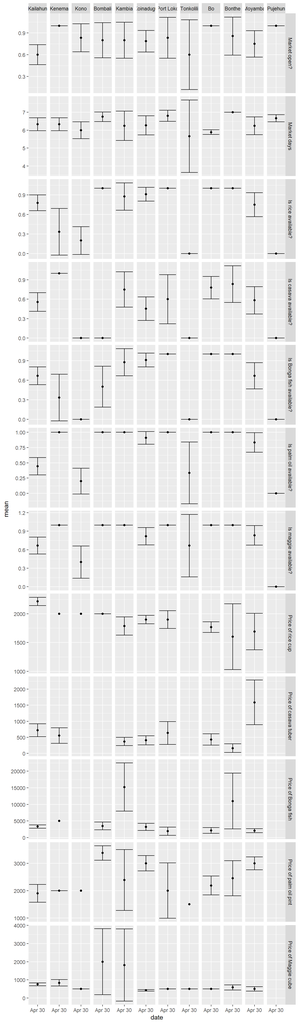

Average responses for a given day (dot) with 95% confidence intervals (whiskers)

### Maps

Showing most recent data available for each district. Each map shows the *ranking* of each district relative to the others.

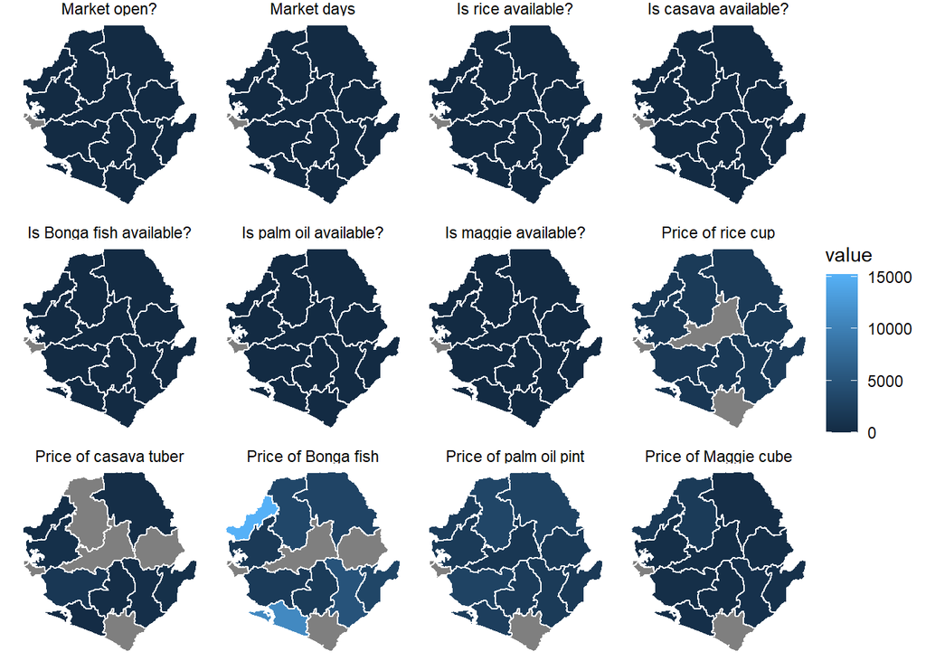

Distribution of standardized variables

### Definitions of measures

Data definitions

| Measure | Definition |
| --- | --- |
| Market open? | Share of respondents reporting that local market is open |
| Market days | Average number of days market was open during past week |
| Is rice available? | Share of respondents reporting that rice is available in markets |
| Is casava available? | Share of respondents reporting that cassava is available in markets |
| Is Bonga fish available? | Share of respondents reporting that Bonga fish is available in markets |
| Is palm oil available? | Share of respondents reporting that palm oil is available in markets |
| Is maggie available? | Share of respondents reporting that maggie is available in markets |
| Price of rice cup | Average price paid for a cup of rice |
| Price of casava tuber | Average price paid for a casava tuber |
| Price of Bonga fish | Average price paid for Bonga fish |
| Price of palm oil pint | Average price paid for palm oil pint |
| Price of Maggie cube | Average price paid for Maggie cube |

## food security

### Current averages

Mean responses in each District (most recent date)

| District | Date | Days ate less prefered food | Days asked for food help | Days reduced adult male food | Days reduced adult female food | Days reduced adult boys food | Days reduced adult girls food | Days ate fewer times | Days did not eat |
| --- | --- | --- | --- | --- | --- | --- | --- | --- | --- |
| Kailahun | 2020-04-30 | 2.33 | 8.20 | 3.47 | 3.47 | 8.40 | 8.40 | 10.00 | 2.13 |
| Kenema | 2020-04-30 | 3.00 | 2.67 | 5.00 | 3.67 | 1.00 | 1.00 | 3.67 | 1.33 |
| Kono | 2020-04-30 | 2.17 | 2.67 | 2.50 | 2.50 | 2.33 | 2.00 | 2.00 | 1.33 |
| Bombali | 2020-04-30 | 2.60 | 3.00 | 2.60 | 2.60 | 1.80 | 1.40 | 2.80 | 1.40 |
| Kambia | 2020-04-30 | 1.50 | 1.30 | 2.30 | 2.20 | 1.00 | 1.00 | 1.90 | 1.00 |
| Koinadugu | 2020-04-30 | 1.57 | 1.43 | 1.57 | 1.57 | 1.57 | 1.57 | 1.50 | 1.07 |
| Port Loko | 2020-04-30 | 1.83 | 1.83 | 1.83 | 1.83 | 1.67 | 1.67 | 2.00 | 1.00 |
| Tonkolili | 2020-04-30 | 2.60 | 2.80 | 3.00 | 3.00 | 2.40 | 21.60 | 3.00 | 1.20 |
| Bo | 2020-04-30 | 2.67 | 1.89 | 2.33 | 2.22 | 1.11 | 1.11 | 2.22 | 1.33 |
| Bonthe | 2020-04-30 | 2.29 | 1.29 | 3.00 | 3.00 | 3.00 | 3.00 | 1.29 | 1.29 |
| Moyamba | 2020-04-30 | 1.88 | 1.06 | 2.25 | 2.19 | 1.50 | 1.38 | 1.81 | 1.38 |
| Pujehun | 2020-04-30 | 2.83 | 2.67 | 4.67 | 4.67 | 4.67 | 4.67 | 3.50 | 1.00 |

### Time trends

[output not shown]

[output cut: 137 more lines]

[output not shown]

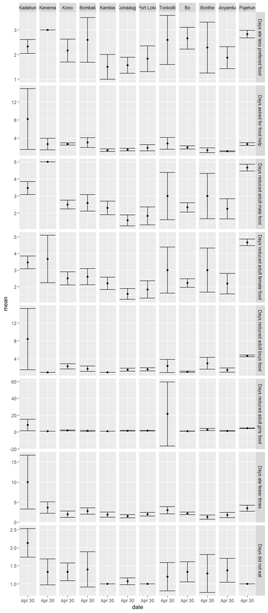

Average responses for a given day (dot) with 95% confidence intervals (whiskers)

### Maps

Showing most recent data available for each district. Each map shows the *ranking* of each district relative to the others.

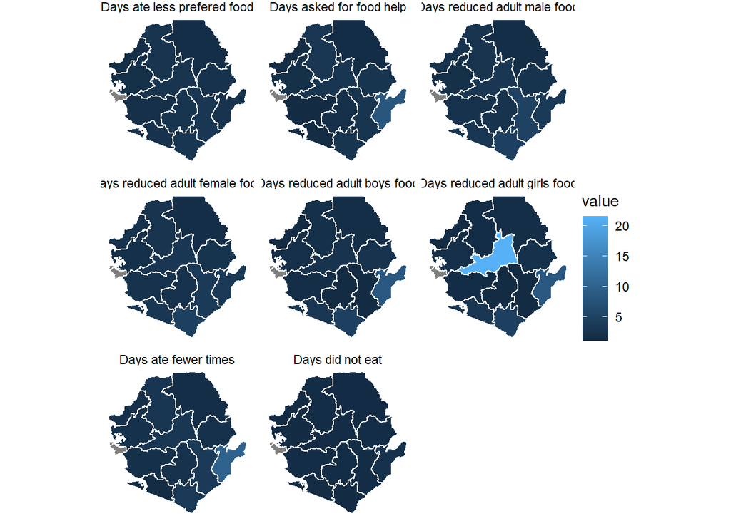

Distribution of standardized variables

### Definitions of measures

Data definitions

| Measure | Definition |
| --- | --- |
| Days ate less prefered food | Days in past week where household ate “less preferred foods” |
| Days asked for food help | Days in past week where household asked for help from relatives or friends for food? |
| Days reduced adult male food | Days in past week where household reduced portions served per meal for adult males? |
| Days reduced adult female food | Days in past week where household reduced portions served per meal for adult females? |
| Days reduced adult boys food | Days in past week where household reduced portions served per meal for boys under age 10 |
| Days reduced adult girls food | Days in past week where household reduced portions/quantities served per meal for girls under age 10 |
| Days ate fewer times | Days in past week where household ate fewer times per day than normal for this time of year |
| Days did not eat | Days in past week where household spent whole day without eating? |

## farming

### Current averages

Mean responses in each District (most recent date)

| District | Date | Less hired labour | Less family labour | Fewer inputs | Lower harvest | Expect lower prices | Less likely to sell crops |
| --- | --- | --- | --- | --- | --- | --- | --- |
| Kailahun | 2020-04-30 | 4.92 | 4.50 | 3.00 | 5.17 | 3.92 | 2.58 |
| Kenema | 2020-04-30 | 5.00 | 4.67 | 3.33 | 4.33 | 4.67 | 3.67 |
| Kono | 2020-04-30 | 2.20 | 2.60 | 3.60 | 3.80 | 3.00 | 2.40 |
| Bombali | 2020-04-30 | 3.00 | 4.00 | 5.00 | 5.00 | 4.00 | 1.50 |
| Kambia | 2020-04-30 | 4.00 | 3.75 | 3.75 | 4.25 | 4.50 | 3.00 |
| Koinadugu | 2020-04-30 | 3.64 | 4.45 | 4.36 | 4.18 | 3.55 | 3.91 |
| Port Loko | 2020-04-30 | NaN | NaN | NaN | NaN | NaN | NaN |
| Tonkolili | 2020-04-30 | 5.00 | 5.50 | 5.00 | 5.50 | 4.75 | 2.00 |
| Bo | 2020-04-30 | 3.83 | 4.00 | 4.67 | 4.50 | 4.00 | 2.17 |
| Bonthe | 2020-04-30 | 4.75 | 3.25 | 6.00 | 6.00 | 3.50 | 3.00 |
| Moyamba | 2020-04-30 | 3.38 | 4.12 | 4.12 | 4.25 | 3.50 | 2.12 |
| Pujehun | 2020-04-30 | 3.00 | 3.00 | 3.00 | 3.00 | 4.50 | 3.00 |

### Time trends

[output not shown]

[output cut: 89 more lines]

[output not shown]

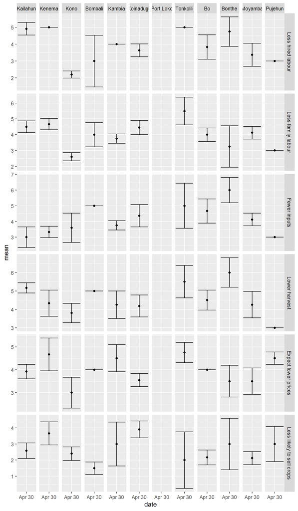

Average responses for a given day (dot) with 95% confidence intervals (whiskers)

### Maps

Showing most recent data available for each district. Each map shows the *ranking* of each district relative to the others.

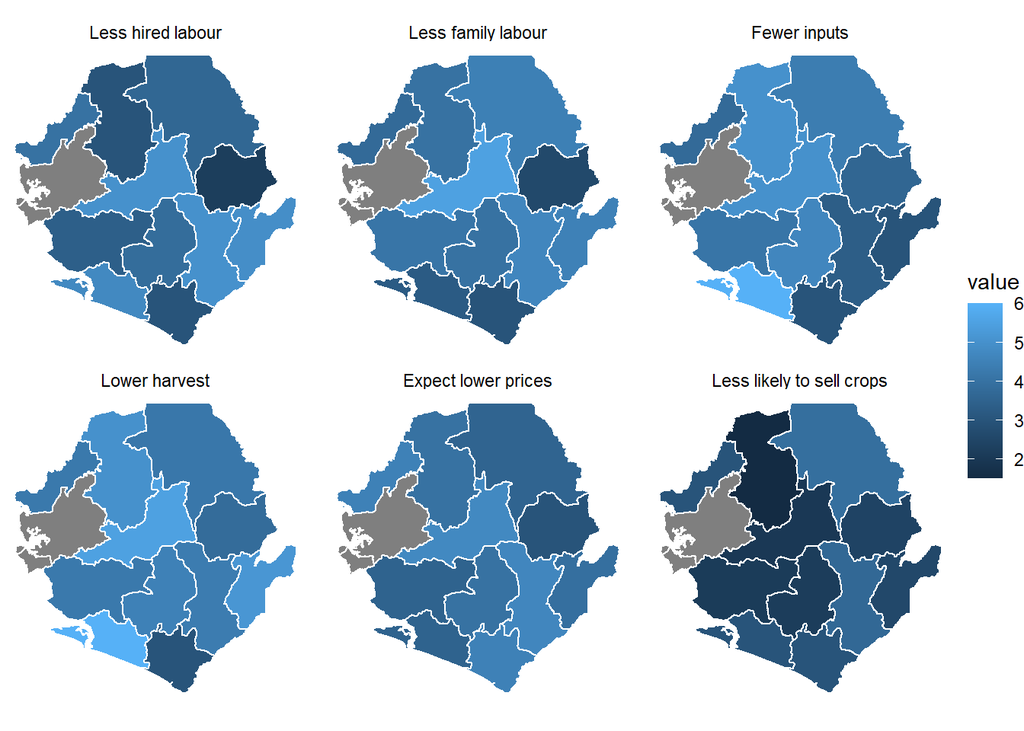

Distribution of standardized variables

### Definitions of measures

Data definitions

| Measure | Definition |
| --- | --- |
| Less hired labour | Relative to last year, fewer hired farm labour |
| Less family labour | Relative to last year, fewer family farm labour |
| Fewer inputs | Relative to last year, fewer farm inputs used |
| Lower harvest | Relative to last year, lower harvest |
| Expect lower prices | Relative to last year, expect lower prices |
| Less likely to sell crops | Relative to last year, less likely to sell crops |

## business

### Current averages

Mean responses in each District (most recent date)

| District | Date | Business closed | Work closed |
| --- | --- | --- | --- |
| Kailahun | 2020-04-30 | 2.67 | NaN |
| Kenema | 2020-04-30 | NaN | NaN |
| Kono | 2020-04-30 | 1.00 | NaN |
| Bombali | 2020-04-30 | NaN | 4.0 |
| Kambia | 2020-04-30 | 3.50 | 2.0 |
| Koinadugu | 2020-04-30 | 5.00 | 5.0 |
| Port Loko | 2020-04-30 | 5.00 | 2.4 |
| Tonkolili | 2020-04-30 | NaN | 5.0 |
| Bo | 2020-04-30 | 3.50 | 4.0 |
| Bonthe | 2020-04-30 | 5.00 | 5.0 |
| Moyamba | 2020-04-30 | 4.25 | 1.5 |
| Pujehun | 2020-04-30 | 3.50 | 3.0 |

### Time trends

[output not shown]

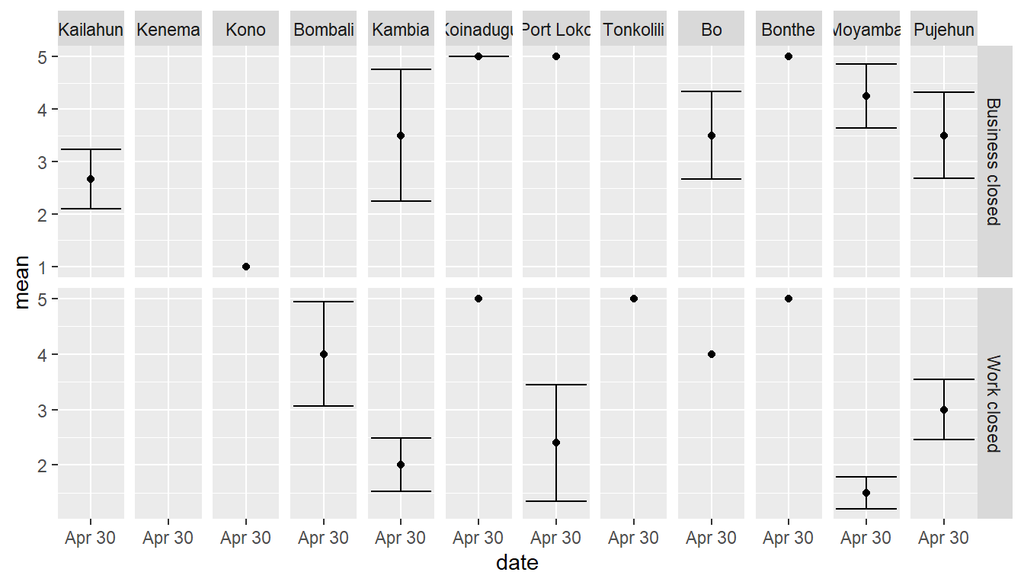

Average responses for a given day (dot) with 95% confidence intervals (whiskers)

### Maps

Showing most recent data available for each district. Each map shows the *ranking* of each district relative to the others.

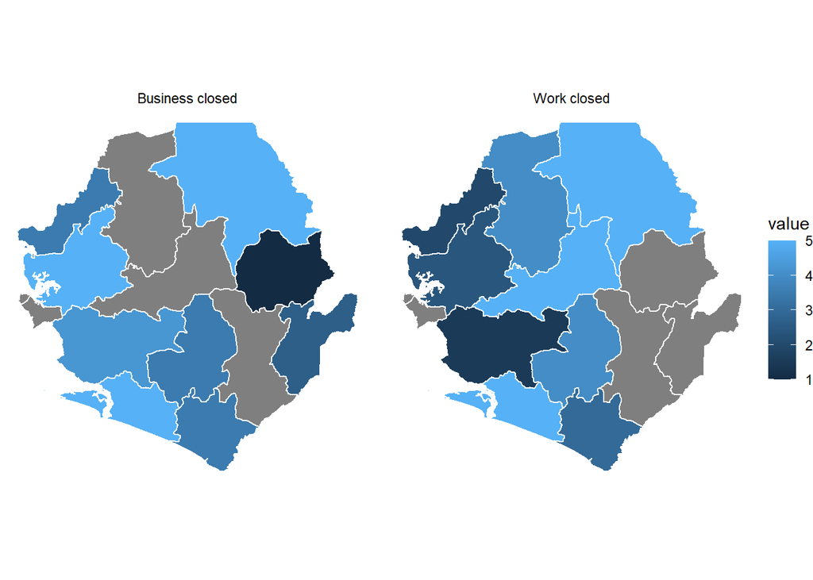

Distribution of standardized variables

### Definitions of measures

Data definitions

| Measure | Definition |
| --- | --- |
| Business closed | Share of respondents that say business is closed |
| Work closed | Share of respondents that report their work is closed |

## social distancing

### Current averages

Mean responses in each District (most recent date)

| District | Date | People in and out of house | Leave house? | Keep distance in markets |
| --- | --- | --- | --- | --- |
| Kailahun | 2020-04-30 | 7.80 | 2.62 | 0.93 |
| Kenema | 2020-04-30 | 0.00 | 7.00 | 1.00 |
| Kono | 2020-04-30 | 0.50 | 4.67 | 1.00 |
| Bombali | 2020-04-30 | 0.60 | 7.00 | 1.00 |
| Kambia | 2020-04-30 | 1.10 | 3.20 | 0.60 |
| Koinadugu | 2020-04-30 | 8.50 | 2.90 | 0.64 |
| Port Loko | 2020-04-30 | 3.17 | 5.25 | 0.67 |
| Tonkolili | 2020-04-30 | 0.00 | 3.00 | 1.00 |
| Bo | 2020-04-30 | 2.78 | 2.50 | 0.89 |
| Bonthe | 2020-04-30 | 1.43 | 5.50 | 0.57 |
| Moyamba | 2020-04-30 | 0.81 | 3.17 | 0.56 |
| Pujehun | 2020-04-30 | 7.83 | 2.33 | 1.00 |

### Time trends

[output not shown]

[output cut: 17 more lines]

[output not shown]

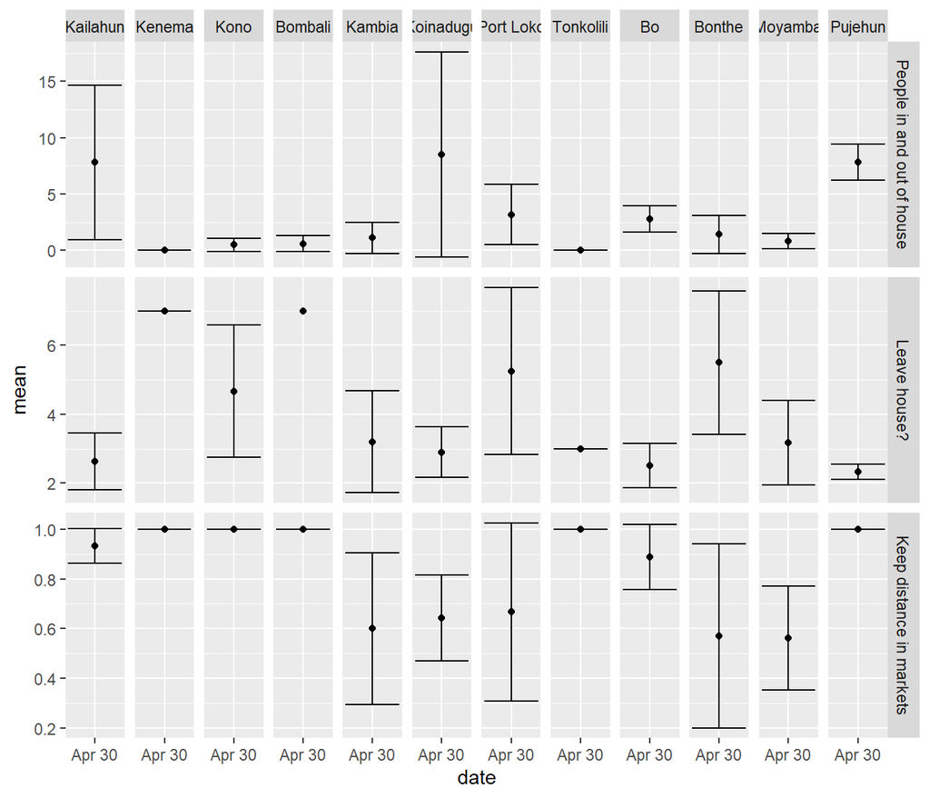

Average responses for a given day (dot) with 95% confidence intervals (whiskers)

### Maps

Showing most recent data available for each district. Each map shows the *ranking* of each district relative to the others.

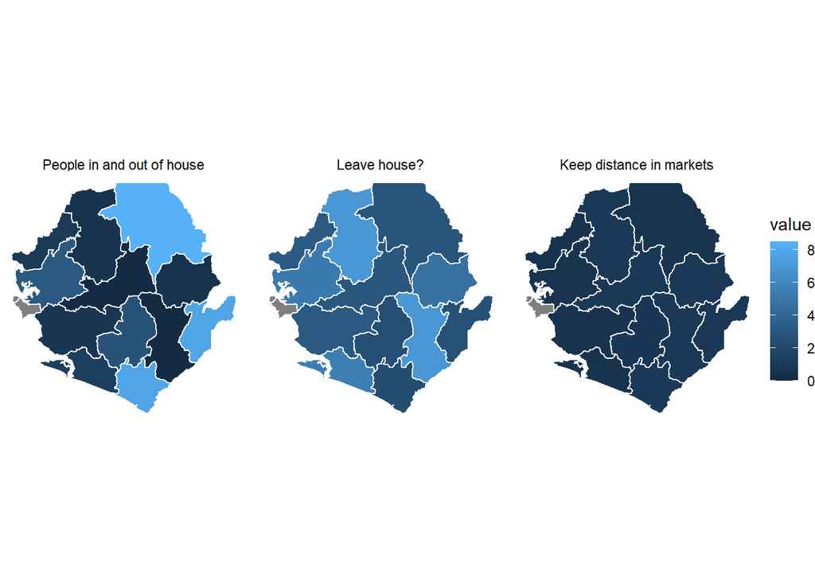

Distribution of standardized variables

### Definitions of measures

Data definitions

| Measure | Definition |
| --- | --- |
| People in and out of house | Average nr of people that come in and out of house |
| Leave house? | Share of respondents reporting they left house day before |
| Keep distance in markets | Average nr of repsontents reporting they keep distance from others when at the market |

## covid

### Current averages

Mean responses in each District (most recent date)

| District | Date | Government COVID-19 information | Access to veronica bucket | Access to clean water | Frequency of handwashing | Worried about COVID-19 |
| --- | --- | --- | --- | --- | --- | --- |
| Kailahun | 2020-04-30 | 1 | 0.93 | 0.73 | 2.07 | 1.07 |
| Kenema | 2020-04-30 | 1 | 1.00 | 1.00 | 1.33 | 1.00 |
| Kono | 2020-04-30 | 1 | 0.67 | 1.00 | 1.17 | 1.00 |
| Bombali | 2020-04-30 | 1 | 0.60 | 1.00 | 1.00 | 1.00 |
| Kambia | 2020-04-30 | 1 | 0.70 | 1.00 | 1.00 | 1.10 |
| Koinadugu | 2020-04-30 | 1 | 0.93 | 0.79 | 1.21 | 1.00 |
| Port Loko | 2020-04-30 | 1 | 1.00 | 1.00 | 1.17 | 1.00 |
| Tonkolili | 2020-04-30 | 1 | 1.00 | 1.00 | 1.00 | 1.00 |
| Bo | 2020-04-30 | 1 | 1.00 | 1.00 | 1.22 | 1.00 |
| Bonthe | 2020-04-30 | 1 | 0.71 | 1.00 | 1.00 | 1.00 |
| Moyamba | 2020-04-30 | 1 | 0.75 | 1.00 | 1.12 | 1.00 |
| Pujehun | 2020-04-30 | 1 | 1.00 | 0.83 | 1.00 | 1.00 |

### Time trends

[output not shown]

[output cut: 65 more lines]

[output not shown]

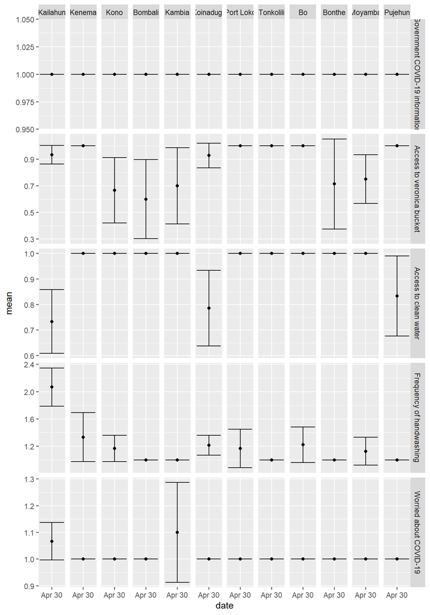

Average responses for a given day (dot) with 95% confidence intervals (whiskers)

### Maps

Showing most recent data available for each district. Each map shows the *ranking* of each district relative to the others.

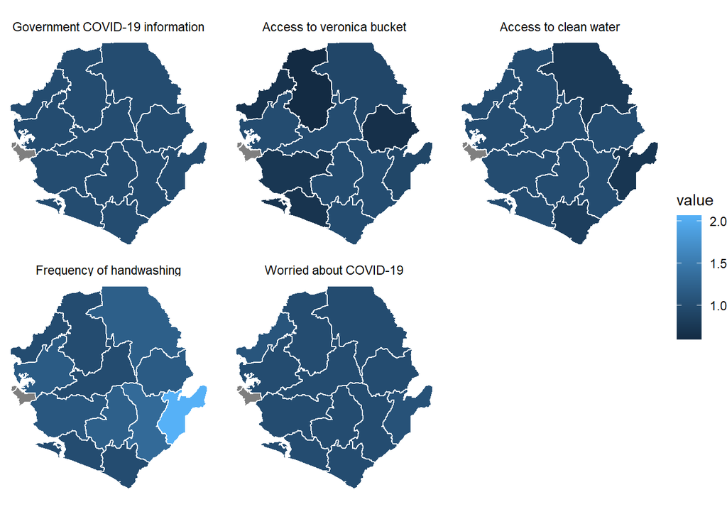

Distribution of standardized variables

### Definitions of measures

Data definitions

| Measure | Definition |
| --- | --- |
| Government COVID-19 information | Share of respondents who receive information about COVID-19 from the government |
| Access to veronica bucket | Share of respondents that have access to a veronica bucket |
| Access to clean water | Share of respondents that have access to clean water to wash your hands |
| Frequency of handwashing | Average nr of times respondents wash hands per day |
| Worried about COVID-19 | Share of respondents that are worried about COVID-19 |

## illness

### Current averages

Mean responses in each District (most recent date)

| District | Date | Times visited clinic past week | Clinic can help |
| --- | --- | --- | --- |
| Kailahun | 2020-04-30 | 1.00 | 1.07 |
| Kenema | 2020-04-30 | NaN | 1.33 |
| Kono | 2020-04-30 | 2.00 | 1.17 |
| Bombali | 2020-04-30 | 3.00 | 1.60 |
| Kambia | 2020-04-30 | NaN | 1.30 |
| Koinadugu | 2020-04-30 | 1.33 | 1.57 |
| Port Loko | 2020-04-30 | 2.00 | 1.17 |
| Tonkolili | 2020-04-30 | 0.00 | 1.80 |
| Bo | 2020-04-30 | 0.00 | 1.11 |
| Bonthe | 2020-04-30 | 1.00 | 1.29 |
| Moyamba | 2020-04-30 | NaN | 1.25 |
| Pujehun | 2020-04-30 | NaN | 1.83 |

### Time trends

[output not shown]

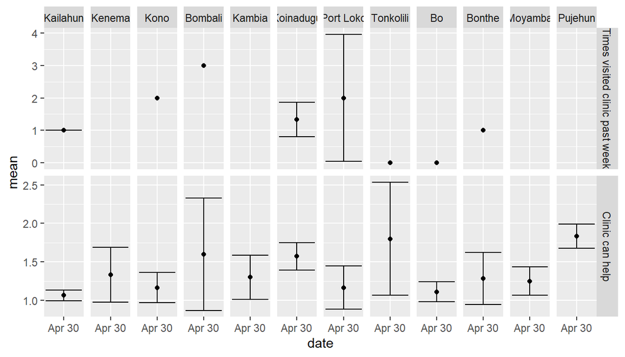

Average responses for a given day (dot) with 95% confidence intervals (whiskers)

### Maps

Showing most recent data available for each district. Each map shows the *ranking* of each district relative to the others.

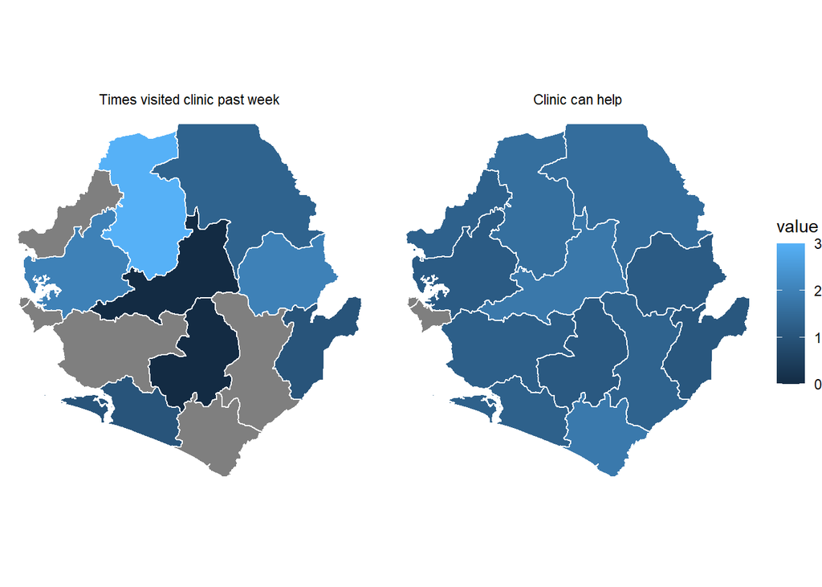

Distribution of standardized variables

### Definitions of measures

Data definitions

| Measure | Definition |
| --- | --- |
| Times visited clinic past week | Average clinic visits in past week |
| Clinic can help | Share of respondents that feel confident that clinic can help |

## All Data

### Browse data

|  | id | date | market_open | market_day | rice_avail | cass_avail | fish_avail | oil_avail | mag_avail | rice_now | cass_price_now | fish_now | oil_now | mag_now | less_prefer | ask_help | reduce_male | reduce_female | reduce_boy | reduce_girl | eat_less | no_eat | farm_hire | farm_time | inputs | harv | price | sell | status | … |
| --- | --- | --- | --- | --- | --- | --- | --- | --- | --- | --- | --- | --- | --- | --- | --- | --- | --- | --- | --- | --- | --- | --- | --- | --- | --- | --- | --- | --- | --- | --- |
| 1 | Kailahun | 2020-04-30 | 0.6 | 6.333 | 0.778 | 0.556 | 0.667 | 0.444 | 0.667 | 2214.286 | 719.8 | 3333.333 | 1899.75 | 750 | 2.333 | 8.2 | 3.467 | 3.467 | 8.4 | 8.4 | 10 | 2.133 | 4.917 | 4.5 | 3 | 5.167 | 3.917 | 2.583 | 2.667 | … |
| 2 | Kenema | 2020-04-30 | 1 | 6.333 | 0.333 | 1 | 0.333 | 1 | 1 | 2000 | 550 | 5000 | 2000 | 833.333 | 3 | 2.667 | 5 | 3.667 | 1 | 1 | 3.667 | 1.333 | 5 | 4.667 | 3.333 | 4.333 | 4.667 | 3.667 |  | … |
| 3 | Kono | 2020-04-30 | 0.833 | 6 | 0.2 | 0 | 0 | 0.2 | 0.4 | 2000 |  |  | 2000 | 500 | 2.167 | 2.667 | 2.5 | 2.5 | 2.333 | 2 | 2 | 1.333 | 2.2 | 2.6 | 3.6 | 3.8 | 3 | 2.4 | 1 | … |
| 4 | Bombali | 2020-04-30 | 0.8 | 6.75 | 1 | 0 | 0.5 | 1 | 1 | 2000 |  | 3500 | 3375 | 2000 | 2.6 | 3 | 2.6 | 2.6 | 1.8 | 1.4 | 2.8 | 1.4 | 3 | 4 | 5 | 5 | 4 | 1.5 |  | … |
| 5 | Kambia | 2020-04-30 | 0.8 | 6.25 | 0.875 | 0.75 | 0.875 | 1 | 1 | 1785.714 | 368 | 15214.286 | 2387.75 | 1813.375 | 1.5 | 1.3 | 2.3 | 2.2 | 1 | 1 | 1.9 | 1 | 4 | 3.75 | 3.75 | 4.25 | 4.5 | 3 | 3.5 | … |
| 6 | Koinadugu | 2020-04-30 | 0.786 | 6.273 | 0.909 | 0.455 | 0.909 | 0.909 | 0.818 | 1900 | 404 | 3196 | 3000 | 422.222 | 1.571 | 1.429 | 1.571 | 1.571 | 1.571 | 1.571 | 1.5 | 1.071 | 3.636 | 4.455 | 4.364 | 4.182 | 3.545 | 3.909 | 5 | … |
| 7 | Port Loko | 2020-04-30 | 0.833 | 6.8 | 1 | 0.6 | 1 | 1 | 1 | 1900 | 633.333 | 1900 | 2000.2 | 500 | 1.833 | 1.833 | 1.833 | 1.833 | 1.667 | 1.667 | 2 | 1 |  |  |  |  |  |  | 5 | … |
| 8 | Tonkolili | 2020-04-30 | 0.6 | 5.667 | 0 | 0 | 0 | 0.333 | 0.667 |  |  |  | 1500 | 500 | 2.6 | 2.8 | 3 | 3 | 2.4 | 21.6 | 3 | 1.2 | 5 | 5.5 | 5 | 5.5 | 4.75 | 2 |  | … |
| 9 | Bo | 2020-04-30 | 1 | 5.889 | 1 | 0.778 | 1 | 1 | 1 | 1766.667 | 430.143 | 2112 | 2188.889 | 500 | 2.667 | 1.889 | 2.333 | 2.222 | 1.111 | 1.111 | 2.222 | 1.333 | 3.833 | 4 | 4.667 | 4.5 | 4 | 2.167 | 3.5 | … |
| 10 | Bonthe | 2020-04-30 | 0.857 | 7 | 1 | 0.833 | 1 | 1 | 1 | 1599.833 | 159.4 | 11000 | 2450 | 583.333 | 2.286 | 1.286 | 3 | 3 | 3 | 3 | 1.286 | 1.286 | 4.75 | 3.25 | 6 | 6 | 3.5 | 3 | 5 | … |

[output cut: 2 more lines]

### Data summaries

**Technical**: Summary measures on all data.

Data summary

| Name | my_data |
| --- | --- |
| Number of rows | 230 |
| Number of columns | 40 |
| _______________________ |  |
| Column type frequency: |  |
| Date | 1 |
| factor | 1 |
| numeric | 38 |
| ________________________ |  |
| Group variables | None |

**Variable type: Date**

| skim_variable | n_missing | complete_rate | min | max | median | n_unique |
| --- | --- | --- | --- | --- | --- | --- |
| date | 0 | 1 | 2020-04-30 | 2020-04-30 | 2020-04-30 | 1 |

**Variable type: factor**

| skim_variable | n_missing | complete_rate | ordered | n_unique | top_counts |
| --- | --- | --- | --- | --- | --- |
| id | 0 | 1 | FALSE | 12 | Kai: 52, Koi: 32, Puj: 26, Bo: 25 |

**Variable type: numeric**

| skim_variable | n_missing | complete_rate | mean | sd | p0 | p25 | p50 | p75 | p100 | hist |
| --- | --- | --- | --- | --- | --- | --- | --- | --- | --- | --- |
| market_open | 128 | 0.44 | 0.79 | 0.41 | 0 | 1 | 1 | 1.00 | 1 | ▂▁▁▁▇ |
| market_day | 149 | 0.35 | 6.33 | 1.10 | 2 | 6 | 7 | 7.00 | 7 | ▁▁▁▃▇ |
| rice_avail | 149 | 0.35 | 0.73 | 0.45 | 0 | 0 | 1 | 1.00 | 1 | ▃▁▁▁▇ |
| cass_avail | 149 | 0.35 | 0.51 | 0.50 | 0 | 0 | 1 | 1.00 | 1 | ▇▁▁▁▇ |
| fish_avail | 149 | 0.35 | 0.67 | 0.47 | 0 | 0 | 1 | 1.00 | 1 | ▃▁▁▁▇ |
| oil_avail | 149 | 0.35 | 0.75 | 0.43 | 0 | 1 | 1 | 1.00 | 1 | ▂▁▁▁▇ |
| mag_avail | 149 | 0.35 | 0.79 | 0.41 | 0 | 1 | 1 | 1.00 | 1 | ▂▁▁▁▇ |
| rice_now | 171 | 0.26 | 1850.88 | 454.10 | 3 | 1550 | 2000 | 2000.00 | 3000 | ▁▁▅▇▁ |
| cass_price_now | 189 | 0.18 | 641.37 | 882.71 | 0 | 99 | 500 | 1000.00 | 5000 | ▇▁▁▁▁ |
| fish_now | 176 | 0.23 | 5212.37 | 7532.43 | 4 | 1000 | 3000 | 5000.00 | 40000 | ▇▁▁▁▁ |
| oil_now | 169 | 0.27 | 2526.26 | 1091.39 | 1 | 2000 | 2500 | 3000.00 | 4500 | ▂▂▇▆▃ |
| mag_now | 166 | 0.28 | 793.86 | 1450.95 | 0 | 500 | 500 | 500.00 | 10000 | ▇▁▁▁▁ |
| less_prefer | 128 | 0.44 | 2.14 | 1.09 | 1 | 1 | 2 | 3.00 | 5 | ▇▃▇▁▁ |
| ask_help | 128 | 0.44 | 2.74 | 9.59 | 1 | 1 | 1 | 3.00 | 98 | ▇▁▁▁▁ |
| reduce_male | 128 | 0.44 | 2.67 | 1.40 | 1 | 1 | 3 | 3.00 | 5 | ▇▅▇▂▅ |
| reduce_female | 128 | 0.44 | 2.60 | 1.41 | 1 | 1 | 3 | 3.00 | 5 | ▇▅▇▂▃ |
| reduce_boy | 128 | 0.44 | 2.83 | 9.71 | 1 | 1 | 1 | 3.00 | 99 | ▇▁▁▁▁ |
| reduce_girl | 128 | 0.44 | 3.72 | 13.61 | 1 | 1 | 1 | 2.75 | 99 | ▇▁▁▁▁ |
| eat_less | 128 | 0.44 | 3.26 | 9.69 | 1 | 1 | 2 | 3.00 | 99 | ▇▁▁▁▁ |
| no_eat | 128 | 0.44 | 1.34 | 0.81 | 1 | 1 | 1 | 1.00 | 5 | ▇▁▁▁▁ |
| farm_hire | 169 | 0.27 | 3.97 | 1.46 | 1 | 3 | 4 | 5.00 | 7 | ▃▆▃▇▂ |
| farm_time | 169 | 0.27 | 4.11 | 1.28 | 2 | 3 | 4 | 5.00 | 7 | ▇▂▇▁▁ |
| inputs | 169 | 0.27 | 4.07 | 1.84 | 1 | 3 | 4 | 5.00 | 7 | ▃▇▂▆▅ |
| harv | 169 | 0.27 | 4.59 | 1.41 | 1 | 3 | 5 | 5.00 | 7 | ▁▅▂▇▃ |
| price | 169 | 0.27 | 3.85 | 1.06 | 2 | 4 | 4 | 4.00 | 6 | ▂▁▇▂▁ |
| sell | 169 | 0.27 | 2.75 | 1.63 | 1 | 1 | 3 | 4.00 | 5 | ▇▂▅▂▅ |
| status | 212 | 0.08 | 3.72 | 1.67 | 1 | 2 | 5 | 5.00 | 5 | ▂▃▁▁▇ |
| empl_status | 210 | 0.09 | 3.00 | 1.56 | 1 | 2 | 2 | 5.00 | 5 | ▃▇▁▂▆ |
| n_people | 128 | 0.44 | 3.60 | 13.87 | 0 | 0 | 0 | 3.00 | 99 | ▇▁▁▁▁ |
| leave | 170 | 0.26 | 3.50 | 2.70 | 0 | 1 | 3 | 7.00 | 7 | ▇▅▅▁▇ |
| dist_market | 128 | 0.44 | 0.77 | 0.42 | 0 | 1 | 1 | 1.00 | 1 | ▂▁▁▁▇ |
| aware | 128 | 0.44 | 1.00 | 0.00 | 1 | 1 | 1 | 1.00 | 1 | ▁▁▇▁▁ |
| veronica | 128 | 0.44 | 0.85 | 0.36 | 0 | 1 | 1 | 1.00 | 1 | ▂▁▁▁▇ |
| water | 128 | 0.44 | 0.92 | 0.27 | 0 | 1 | 1 | 1.00 | 1 | ▁▁▁▁▇ |
| wash | 128 | 0.44 | 1.25 | 0.62 | 1 | 1 | 1 | 1.00 | 3 | ▇▁▁▁▁ |
| worry | 128 | 0.44 | 1.02 | 0.14 | 1 | 1 | 1 | 1.00 | 2 | ▇▁▁▁▁ |
| n_visits | 217 | 0.06 | 1.31 | 1.32 | 0 | 0 | 1 | 2.00 | 4 | ▆▇▂▃▂ |
| chc_confident | 128 | 0.44 | 1.33 | 0.55 | 1 | 1 | 1 | 2.00 | 4 | ▇▃▁▁▁ |

Notes

[^1]: Niccolo Meriggi (IGC Sierra Leone), Macartan Humphreys (WZB Berlin and Columbia Univerisity), Abou Bakarr Kamara (IGC Sierra Leone), Madison Levine (Wageningen U), Mushfiq Mobarak (Yale University), Wilson Prichard (U Toronto), Ashwini Shridhar (Wageningen U), Peter van der Windt (NYU AD), Maarten Voors (Wageningen University). Feedback welcome! Please get in touch via email at tracking.corona.sl@gmail.com.